# Lecture 4: Introduction to Visualization

### 2.3.2 Step 2: Add Aesthetic Mappings

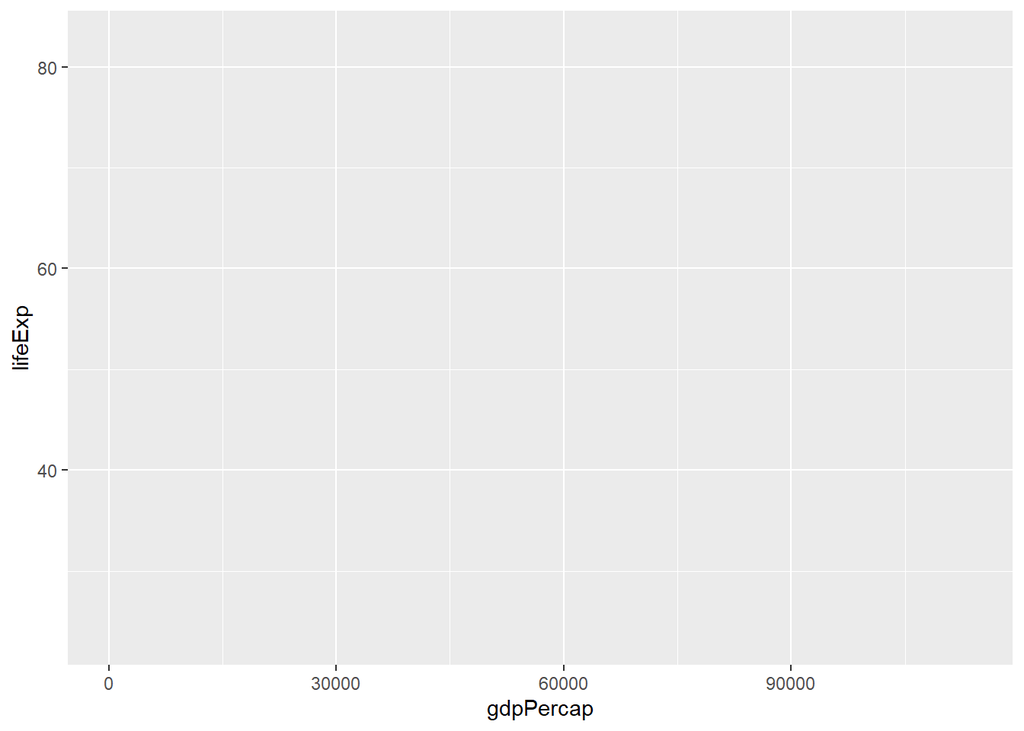

```r
# Step 2: Tell ggplot which variables to use
p2 <- ggplot(data = gapminder, aes(x = gdpPercap, y = lifeExp))
print(p2)
```

Now we have axes! `ggplot2` knows we want GDP per capita on x-axis and life expectancy on y-axis. But still no data points.

### 2.3.3 Step 3: Add a Geometry

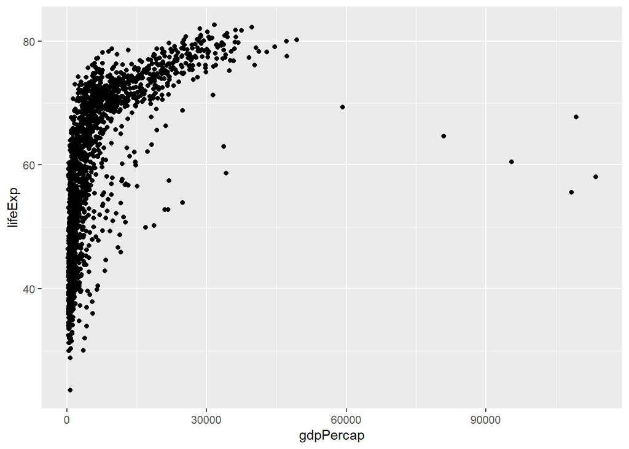

```r
# Step 3: Add points to see the data
p3 <- ggplot(data = gapminder, aes(x = gdpPercap, y = lifeExp)) +
  geom_point()
print(p3)
```

**Economic insight:** Wow! There’s a clear positive relationship between wealth and health. But it’s not linear—looks logarithmic.

### 2.3.4 Step 4: Add More Aesthetic Mappings

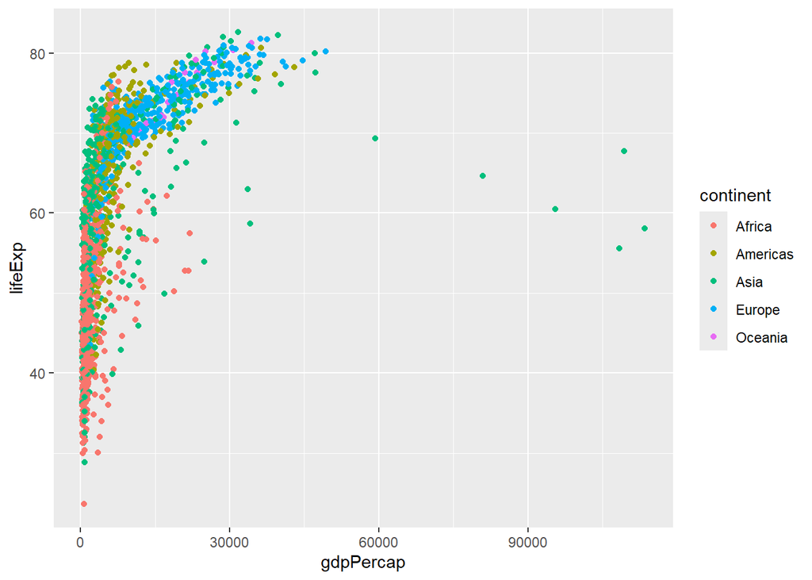

```r
# Step 4: Color by continent to see regional patterns
p4 <- ggplot(data = gapminder, aes(x = gdpPercap, y = lifeExp, color = continent)) +
  geom_point()
print(p4)
```

**Economic insight:** Africa consistently shows lower life expectancy and GDP. Europe and Oceania cluster in the high-wealth, high-health region.

### 2.3.5 Step 5: Add More Geometries

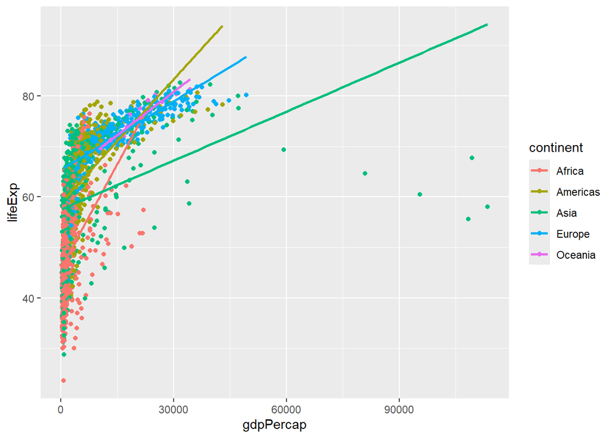

```r
# Step 5: Add a trend line to quantify the relationship
p5 <- ggplot(data = gapminder, aes(x = gdpPercap, y = lifeExp, color = continent)) +
  geom_point() +
  geom_smooth(method = "lm", se = FALSE)
print(p5)
```

### 2.3.6 Step 6: Professional Labels

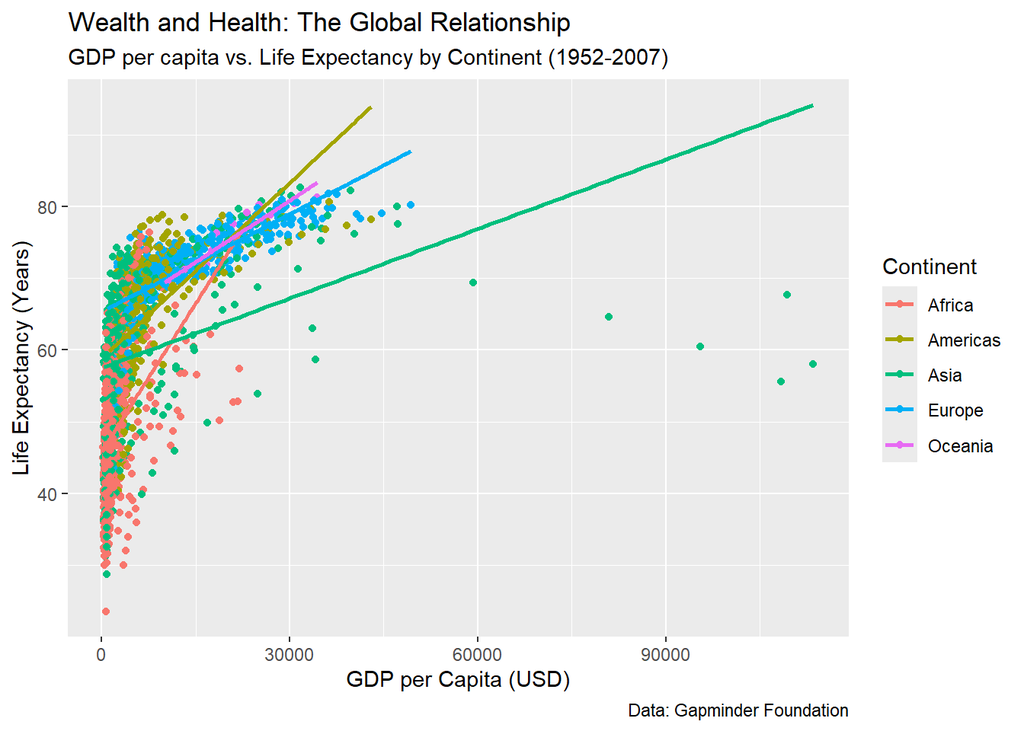

```r
# Step 6: Add publication-quality labels
p6 <- ggplot(data = gapminder, aes(x = gdpPercap, y = lifeExp, color = continent)) +
  geom_point() +
  geom_smooth(method = "lm", se = FALSE) +
  labs(
    title = "Wealth and Health: The Global Relationship",
    subtitle = "GDP per capita vs. Life Expectancy by Continent (1952-2007)",
    x = "GDP per Capita (USD)",
    y = "Life Expectancy (Years)",
    color = "Continent",
    caption = "Data: Gapminder Foundation"
  )
print(p6)
```

### 2.3.7 Step 7: Professional Theme

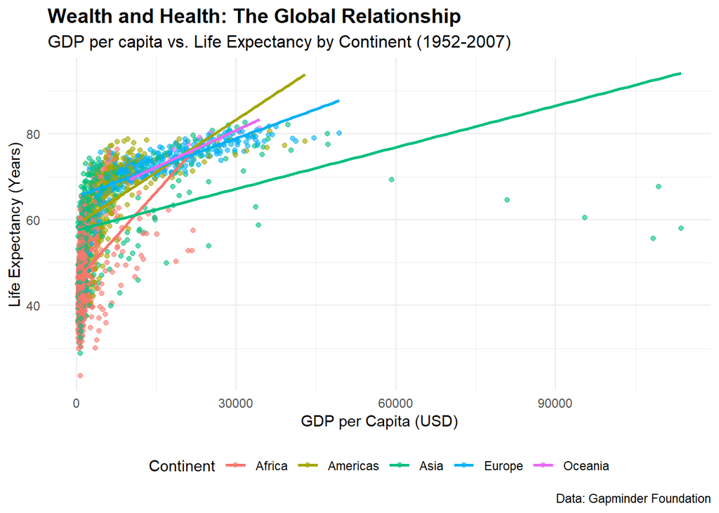

```r
# Step 7: Apply a clean, professional theme
p7 <- ggplot(data = gapminder, aes(x = gdpPercap, y = lifeExp, color = continent)) +
  geom_point(alpha = 0.6) +  # Make points slightly transparent
  geom_smooth(method = "lm", se = FALSE) +
  labs(
    title = "Wealth and Health: The Global Relationship",
    subtitle = "GDP per capita vs. Life Expectancy by Continent (1952-2007)",
    x = "GDP per Capita (USD)",
    y = "Life Expectancy (Years)",
    color = "Continent",
    caption = "Data: Gapminder Foundation"
  ) +
  theme_minimal() +
  theme(
    plot.title = element_text(size = 14, face = "bold"),
    plot.subtitle = element_text(size = 12),
    legend.position = "bottom"
  )
print(p7)
```

**This is publication-ready!** Seven steps from blank canvas to professional economic analysis.

## 2.4 Key ggplot2 Principles

### 2.4.1 1. Aesthetic Mappings vs. Fixed Values

**Caution**

This is the #1 source of `ggplot2` confusion!

```r
# WRONG: This makes all points the same color (and it's not red!)
ggplot(mtcars, aes(x = mpg, y = hp, color = "red")) + geom_point()

# RIGHT: This makes all points red
ggplot(mtcars, aes(x = mpg, y = hp)) + geom_point(color = "red")

# RIGHT: This colors points by a variable
ggplot(mtcars, aes(x = mpg, y = hp, color = cyl)) + geom_point()
```

**Rule:** Inside `aes()` ⟶ varies with data. Outside `aes()` ⟶ fixed value.

### 2.4.2 2. Layer by Layer Construction

Every `+` adds a new layer. Order matters!

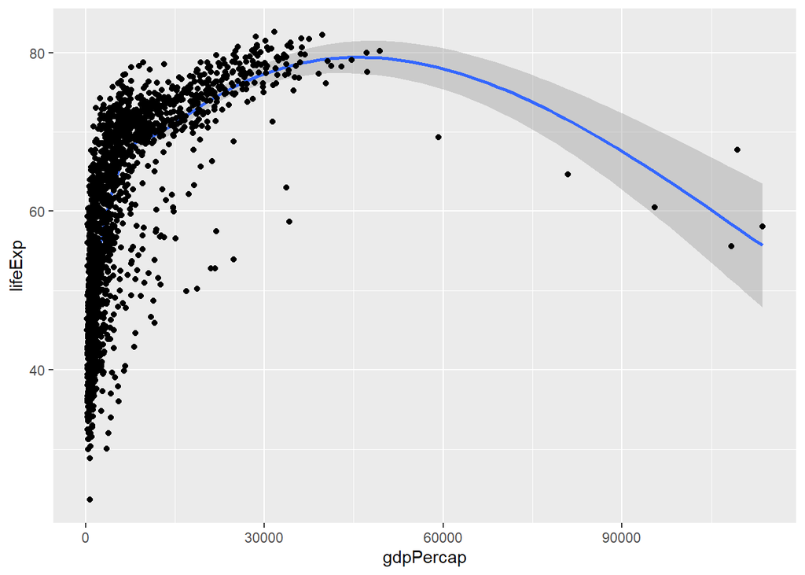

```r
# Points on top of smooth
ggplot(gapminder, aes(x = gdpPercap, y = lifeExp)) +
  geom_smooth() +
  geom_point()
```

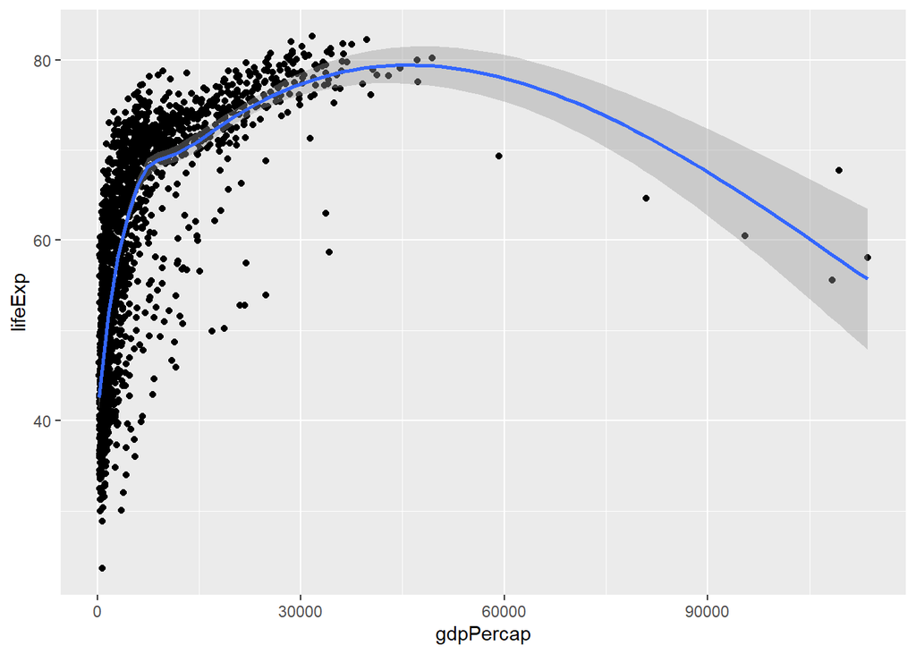

```r
# Smooth on top of points
ggplot(gapminder, aes(x = gdpPercap, y = lifeExp)) +
  geom_point() +
  geom_smooth()
```

### 2.4.3 3. Common Geometries for Economics

```r
# Scatter plots - relationships
geom_point()

# Line plots - time series
geom_line()

# Bar plots - comparisons
geom_col()       # heights are data values
geom_bar()       # heights are counts

# Histograms - distributions
geom_histogram()

# Box plots - comparing distributions
geom_boxplot()
```

# 3 Debugging Interlude: Common ggplot2 Errors

Let’s intentionally make some common mistakes and learn how to fix them.

## 3.1 Error 1: Aesthetic vs. Fixed Values (VERY Common!)

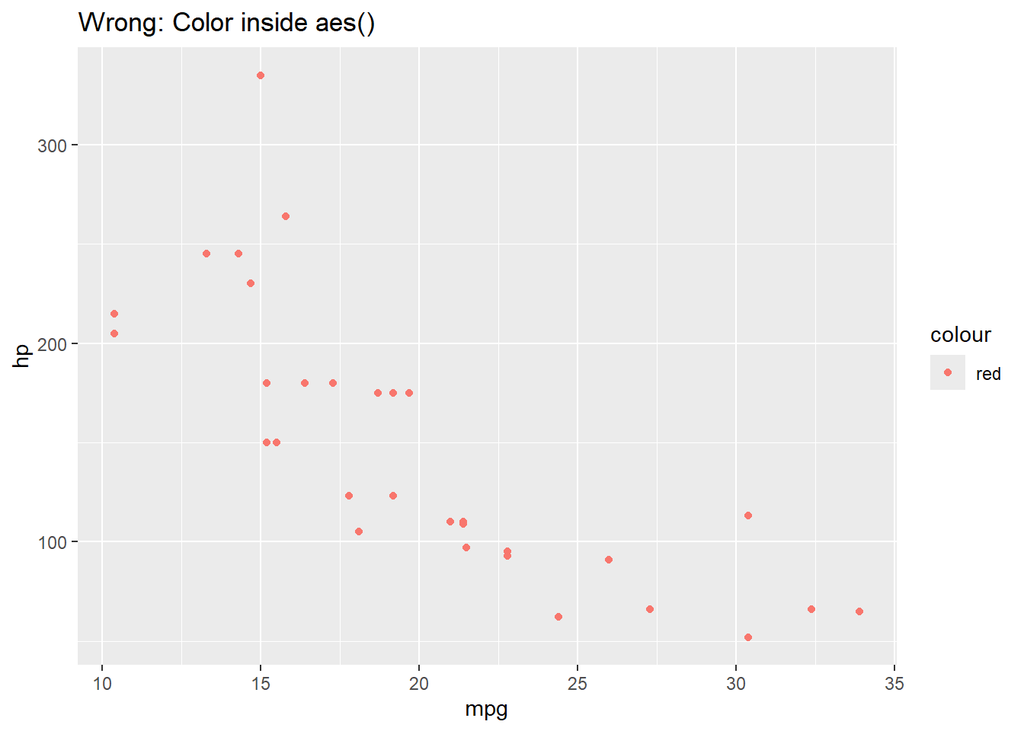

```r
# This WON'T work as expected:
p_wrong <- ggplot(mtcars, aes(x = mpg, y = hp, color = "red")) +
  geom_point() +
  labs(title = "Wrong: Color inside aes()")
print(p_wrong)
```

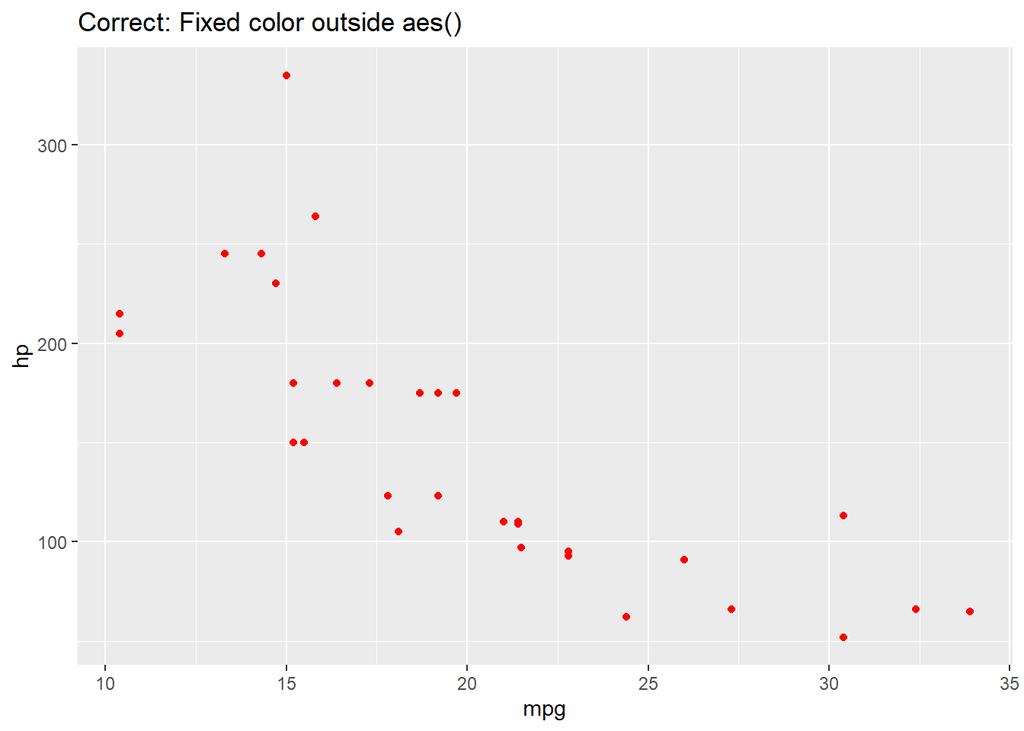

```r
# This WILL work:
p_right <- ggplot(mtcars, aes(x = mpg, y = hp)) +
  geom_point(color = "red") +
  labs(title = "Correct: Fixed color outside aes()")
print(p_right)
```

## 3.2 Error 2: Missing + Between Layers

```r
# This would cause an error:
ggplot(mtcars, aes(x = mpg, y = hp))
  geom_point()
```

## 3.3 Debugging Strategy: Building Plots Layer by Layer

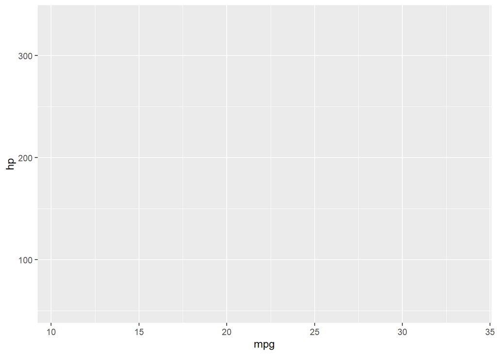

```r
# Step 1: Start with base
p_base <- ggplot(mtcars, aes(x = mpg, y = hp))
print(p_base)  # Will show empty plot
```

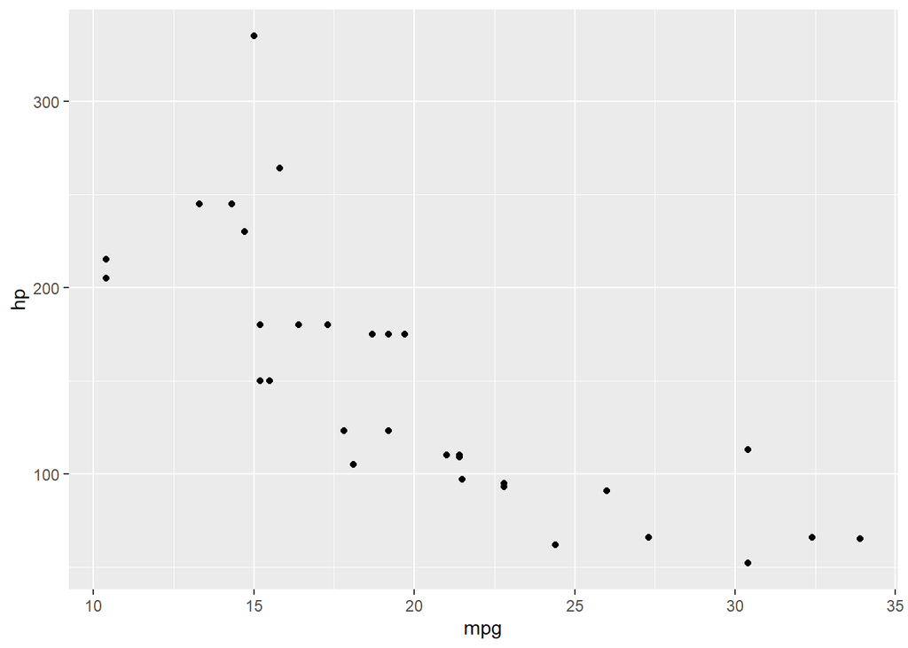

```r
# Step 2: Add geometry
p_points <- p_base + geom_point()
print(p_points)
```

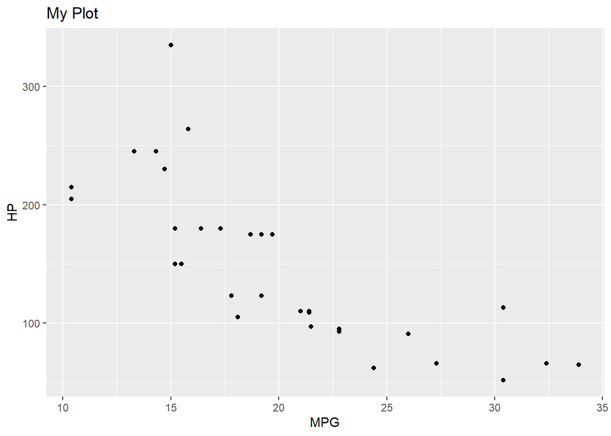

```r
# Step 3: Add labels
p_final <- p_points + labs(title = "My Plot", x = "MPG", y = "HP")
print(p_final)
```

**Your ggplot2 debugging workflow:**

1. **BUILD** plots layer by layer
2. **REMEMBER**: aesthetics vs. fixed values
3. **CHECK** that every layer has a `+` before it
4. **TEST** each layer individually

# 4 Guided Practice (`We Do`)

## 4.1 Challenge: Add Population Information

Looking at our wealth-health plot, I want to incorporate country size (population) into the visualization.

> What aesthetic mapping would show population size?

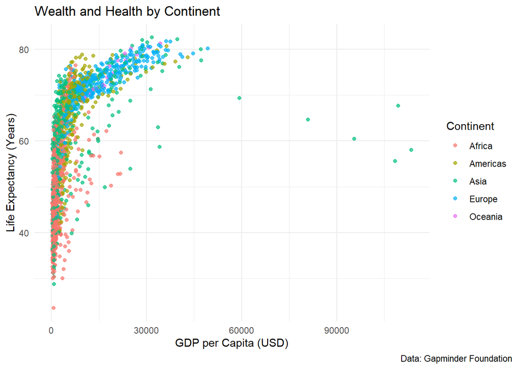

```r
# Our current plot
base_plot <- ggplot(data = gapminder, aes(x = gdpPercap, y = lifeExp, color = continent)) +
  geom_point(alpha = 0.7) +
  labs(
    title = "Wealth and Health by Continent",
    x = "GDP per Capita (USD)",
    y = "Life Expectancy (Years)",
    color = "Continent",
    caption = "Data: Gapminder Foundation"
  ) +
  theme_minimal() +
  theme(
    plot.caption.position = "plot"
  )

print(base_plot)
```

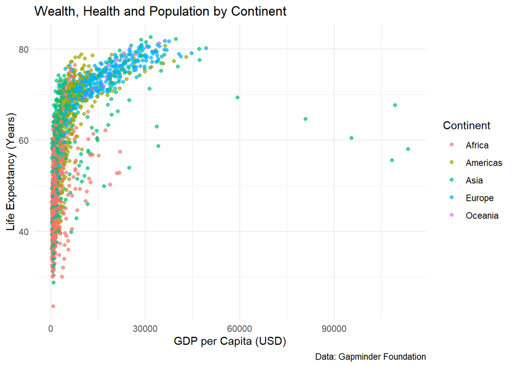

```r
# Add population as ...
enhanced_plot <- ggplot(data = gapminder, aes(x = gdpPercap, y = lifeExp, color = continent)) +
  geom_point(alpha = 0.7) +
  labs(
    title = "Wealth, Health and Population by Continent",
    x = "GDP per Capita (USD)",
    y = "Life Expectancy (Years)",
    color = "Continent",
    caption = "Data: Gapminder Foundation"
  ) +
  theme_minimal()

print(enhanced_plot)
```

**Guided Practice Solution**

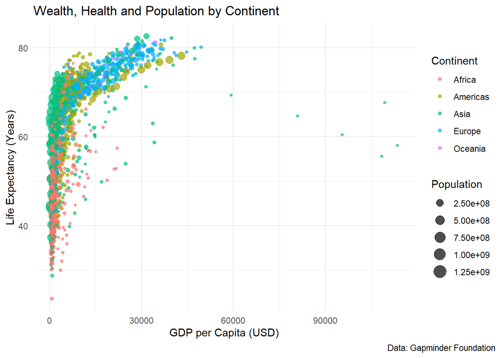

```r
# Add population as point size
enhanced_plot <- ggplot(data = gapminder, aes(x = gdpPercap, y = lifeExp, color = continent, size = pop)) +
  geom_point(alpha = 0.7) +
  labs(
    title = "Wealth, Health and Population by Continent",
    x = "GDP per Capita (USD)",
    y = "Life Expectancy (Years)",
    color = "Continent",
    size = "Population",
    caption = "Data: Gapminder Foundation"
  ) +
  theme_minimal() +
  theme(
    plot.caption.position = "plot"
  )

print(enhanced_plot)
```

**Class discussion:** What economic insights do we see now? Which countries might be those large bubbles in the lower-left (low GDP, high population)?

# 5 Hands-On Practice (`You Do`)

## 5.1 Core Tasks

### 5.1.1 Core 1: Economic Comparison Visualization

Create a publication-quality bar chart comparing **total GDP by continent for the year 2007**. This directly builds on Tuesday’s continental analysis exercises!

Your plot should include:

1. Filter the data to only 2007 (just like Tuesday’s Exercise 3)
2. Calculate total GDP by continent (hint: `gdpPercap * pop` gives total GDP)
3. Create a bar chart with continents on x-axis, total GDP on y-axis
4. Add professional labels and a clean theme
5. Color the bars by continent

**Starter code (this should look familiar from Tuesday!):**

```r
# Step 1: Prepare your data
gdp_2007 <- gapminder %>%
  filter(year == 2007) %>%
  mutate(total_gdp = gdpPercap * pop) %>%
  group_by(continent) %>%
  summarise(total_gdp = sum(total_gdp), .groups = "drop")

# Step 2: Create your plot
ggplot(gdp_2007, aes(x = continent, y = total_gdp)) +
  # Add your layers here
```

**Success criteria:**

- Plot displays correctly
- All continents are labeled clearly
- Y-axis shows total GDP (will be in scientific notation)
- Has informative title and axis labels
- Uses a clean theme

## 5.2 Extension Activities

If you finished the core tasks, try these extension activities:

### 5.2.1 Extension 1: Time Series Challenge

Remember Tuesday when some of you tackled the population giants exercise? Let’s visualize that!

Create a line plot showing **life expectancy over time for the 5 most populous countries in 2007**.

**Tip**

**Hints:**

- This is similar to Tuesday’s “population giants” approach
- Find the 5 most populous countries in 2007
- Filter the full dataset to only those countries
- Use `geom_line()` with country as the color aesthetic
- Consider adding `geom_point()` for individual years

**Bonus:** Add a smooth trend line across all countries using `geom_smooth()`.

### 5.2.2 Extension 2: Advanced Multi-Panel Plot

Create a **faceted plot** showing the wealth-health relationship separately for each continent using `facet_wrap()`.

**Requirements:**

- Scatter plot of GDP per capita vs. life expectancy
- Separate panel for each continent
- Add trend lines to each panel
- Professional labeling

**Starter code:**

```r
ggplot(gapminder, aes(x = gdpPercap, y = lifeExp)) +
  geom_point(alpha = 0.6) +
  geom_smooth(method = "lm", se = FALSE) +
  facet_wrap(~ continent) +
  # Add your customizations
```

### 5.2.3 Extension 3: Create an “Economist-Style” Plot

**Requirements:**

- Use only 2007 data
- Scatter plot with GDP per capita (log scale) vs. life expectancy
- Color points by continent
- Size points by population
- Add trend line
- Clean, minimal theme
- Economist-style fonts and colors if possible

**Advanced features:**

- Log-transform the x-axis using `scale_x_log10()`
- Use custom colors: `scale_color_manual(values = c("Africa" = "#E74C3C", "Americas" = "#3498DB", etc.))`
- Add country labels for outliers using `geom_text()`

## 5.3 Working Solutions

Here are the solutions—but seriously, don’t peek until you’ve wrestled with the problems. The struggle is where the learning happens.

**Core Task Solutions**

### 5.3.1 Core 1 Solution

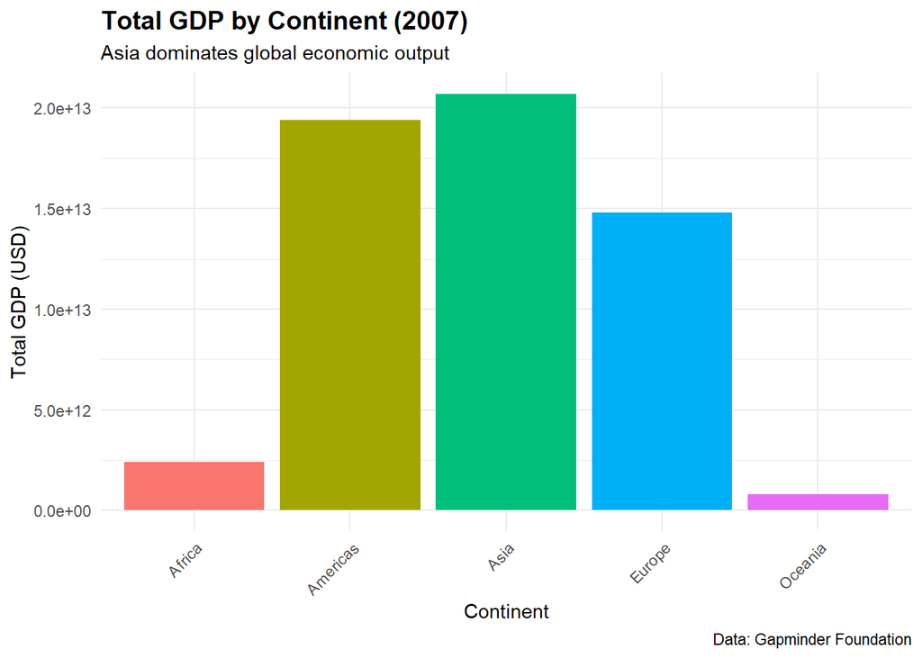

```r
gdp_2007 <- gapminder %>%
  filter(year == 2007) %>%
  mutate(total_gdp = gdpPercap * pop) %>%
  group_by(continent) %>%
  summarise(total_gdp = sum(total_gdp), .groups = "drop")

ggplot(gdp_2007, aes(x = continent, y = total_gdp, fill = continent)) +
  geom_col(show.legend = FALSE) +
  scale_y_continuous(labels = scales::scientific) +
  labs(
    title = "Total GDP by Continent (2007)",
    subtitle = "Asia dominates global economic output",
    x = "Continent",
    y = "Total GDP (USD)",
    caption = "Data: Gapminder Foundation"
  ) +
  theme_minimal() +
  theme(
    plot.title = element_text(size = 14, face = "bold"),
    axis.text.x = element_text(angle = 45, hjust = 1)
  )
```

**Extension Activity Solutions**

### 5.3.2 Extension 1: Time Series

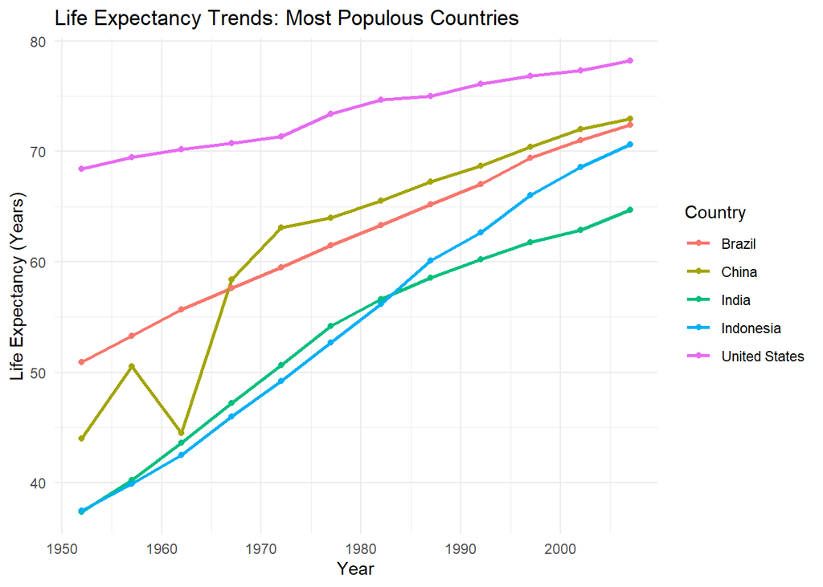

```r
# Find 5 most populous countries in 2007
top_countries <- gapminder %>%
  filter(year == 2007) %>%
  arrange(desc(pop)) %>%
  slice_head(n = 5) %>%
  pull(country)   # pull() extracts a single column and returns a vector

# Create time series plot
gapminder %>%
  filter(country %in% top_countries) %>%
  ggplot(aes(x = year, y = lifeExp, color = country)) +
  geom_line(size = 1) +
  geom_point() +
  labs(
    title = "Life Expectancy Trends: Most Populous Countries",
    x = "Year",
    y = "Life Expectancy (Years)",
    color = "Country"
  ) +
  theme_minimal()
```

### 5.3.3 Extension 2: Faceted Plot

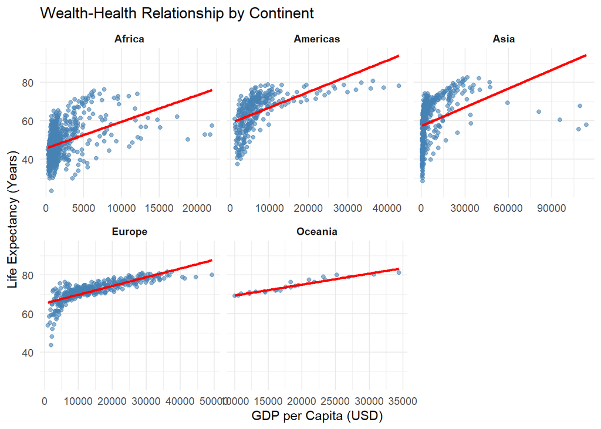

```r
ggplot(gapminder, aes(x = gdpPercap, y = lifeExp)) +
  geom_point(alpha = 0.6, color = "steelblue") +
  geom_smooth(method = "lm", se = FALSE, color = "red") +
  facet_wrap(~ continent, scales = "free_x") +
  labs(
    title = "Wealth-Health Relationship by Continent",
    x = "GDP per Capita (USD)",
    y = "Life Expectancy (Years)"
  ) +
  theme_minimal() +
  theme(strip.text = element_text(face = "bold"))
```

### 5.3.4 Extension 3: Economist Style Plot

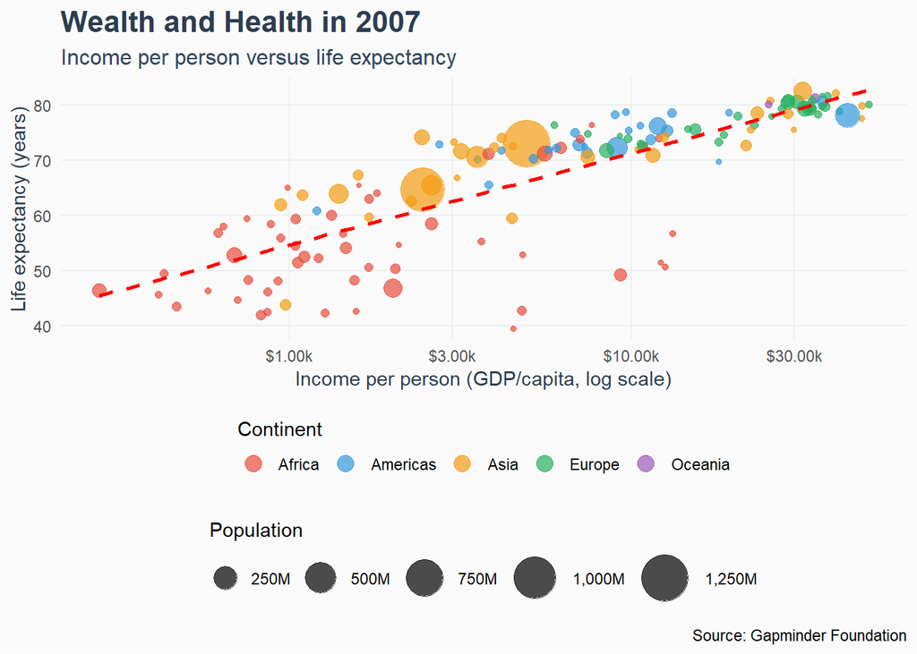

```r
# Create an Economist-style wealth-health plot
economist_plot <- gapminder %>%
  filter(year == 2007) %>%
  ggplot(aes(x = gdpPercap, y = lifeExp)) +
  geom_point(aes(color = continent, size = pop), alpha = 0.7) +
  geom_smooth(method = "lm", se = FALSE, color = "red", linetype = "dashed") +
  scale_x_log10(
    labels = scales::dollar_format(scale = 1e-3, suffix = "k"),
    breaks = c(1000, 3000, 10000, 30000)
  ) +
  scale_y_continuous(
    breaks = seq(40, 85, by = 10)
  ) +
  scale_color_manual(
    values = c(
      "Africa" = "#E74C3C",
      "Americas" = "#3498DB",
      "Asia" = "#F39C12",
      "Europe" = "#27AE60",
      "Oceania" = "#9B59B6"
    )
  ) +
  scale_size_continuous(
    range = c(1, 12),
    labels = scales::comma_format(scale = 1e-6, suffix = "M")
  ) +
  labs(
    title = "Wealth and Health in 2007",
    subtitle = "Income per person versus life expectancy",
    x = "Income per person (GDP/capita, log scale)",
    y = "Life expectancy (years)",
    color = "Continent",
    size = "Population",
    caption = "Source: Gapminder Foundation"
  ) +
  theme_minimal() +
  theme(
    plot.title = element_text(size = 16, face = "bold", color = "#2C3E50"),
    plot.subtitle = element_text(size = 12, color = "#34495E"),
    axis.title = element_text(size = 11, color = "#2C3E50"),
    legend.position = "bottom",
    legend.box = "vertical",
    panel.grid.minor = element_blank(),
    panel.grid.major = element_line(color = "#ECF0F1", size = 0.5),
    plot.background = element_rect(fill = "#FAFAFA", color = NA)
  ) +
  guides(
    color = guide_legend(
      override.aes = list(size = 4),
      title.position = "top",
      order = 1
    ),
    size = guide_legend(
      title.position = "top",
      order = 2
    )
  )

print(economist_plot)
```

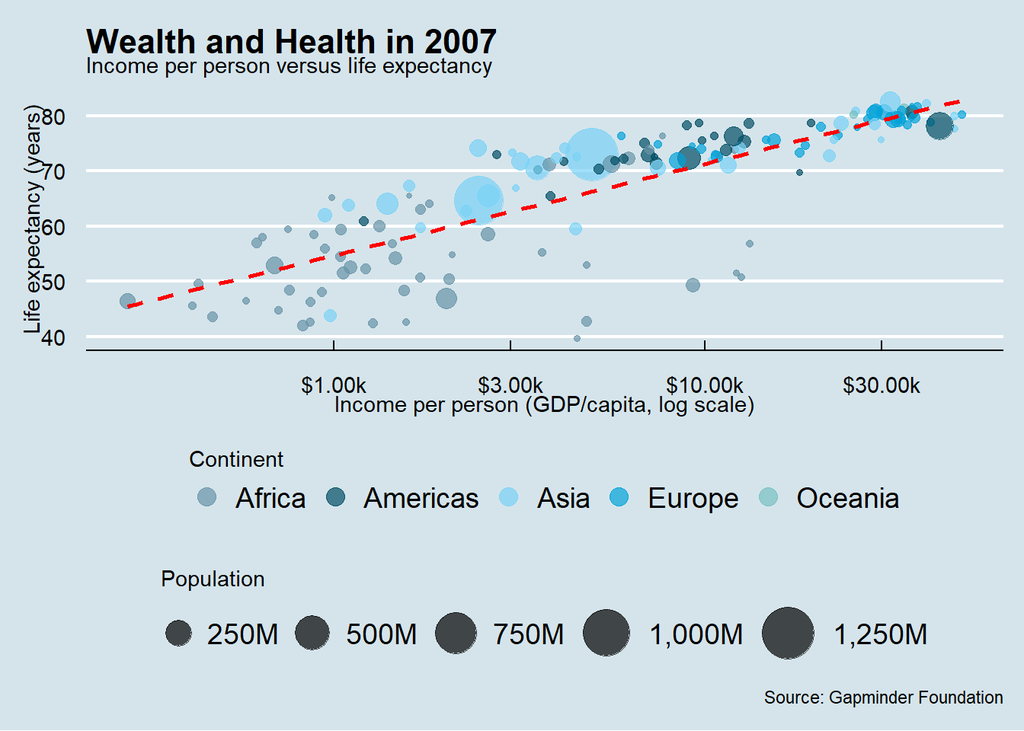

```r
# There are professional theme packages available through the ggthemes package
# Use the the actual theme_economist() for a much more authentic and cleaner plot

# Note: You'll need ggthemes package for theme_economist()
# install.packages("ggthemes") if you don't have it

library(ggthemes)

economist_plot2 <- gapminder %>%
  filter(year == 2007) %>%
  ggplot(aes(x = gdpPercap, y = lifeExp)) +
  geom_point(aes(color = continent, size = pop), alpha = 0.7) +
  geom_smooth(method = "lm", se = FALSE, color = "red", linetype = "dashed") +
  scale_x_log10(
    labels = scales::dollar_format(scale = 1e-3, suffix = "k"),
    breaks = c(1000, 3000, 10000, 30000)
  ) +
  scale_y_continuous(
    breaks = seq(40, 85, by = 10)
  ) +
  scale_color_economist() +  # Economist color palette
  scale_size_continuous(
    range = c(1, 12),
    labels = scales::comma_format(scale = 1e-6, suffix = "M")
  ) +
  labs(
    title = "Wealth and Health in 2007",
    subtitle = "Income per person versus life expectancy",
    x = "Income per person (GDP/capita, log scale)",
    y = "Life expectancy (years)",
    color = "Continent",
    size = "Population",
    caption = "Source: Gapminder Foundation"
  ) +
  theme_economist() +  # Official Economist theme
  theme(
    legend.position = "bottom",
    legend.box = "vertical"
  ) +
  guides(
    color = guide_legend(
      override.aes = list(size = 4),
      title.position = "top",
      order = 1
    ),
    size = guide_legend(
      title.position = "top",
      order = 2
    )
  )

print(economist_plot2)
```

# 6 Wrap-up & Looking Ahead

## 6.1 What We Learned Today

**The Grammar of Graphics:**

- **Data + Aesthetics + Geometries** = Complete plots
- **Layer-by-layer construction** for complex visualizations
- **Aesthetic mappings vs. fixed values**—the most important distinction

**Professional Plotting Skills:**

- Publication-quality labels and themes
- Color and size aesthetics for additional dimensions
- Debugging plots by building step-by-step

## 6.2 Next Lecture Preview: Automation—Functions & Iteration

**Tuesday we tackle code efficiency.** You’ll learn to:

- Write custom functions to eliminate repetitive code
- Use iteration (`for` loops and `apply` functions) to automate tasks
- Apply the DRY principle: “Don’t Repeat Yourself”

## 6.3 Assignment 1 Posted Tomorrow

**Assignment 1: Tidyverse Fundamentals**

- **Posted:** Friday, September 12 at 5 PM
- **Due:** Saturday, September 20 at 8 AM
- **Focus:** Everything we’ve covered so far—`dplyr` + `ggplot2`

### 6.3.1 Reading for Tuesday

**Required reading:**

- **R4DS Chapter 25 (Functions)** – Writing your own functions
- **R4DS Chapter 26 (Iteration)** – Repeating operations efficiently
- **R4DS Chapter 27.4 (`apply`)** & **27.5 (`for` loops)** – Different iteration approaches

**Suggested:**

- **ERP Chapter 3 (Programming)** – More advanced programming concepts
- [vector & lists tutorial](https://jennybc.github.io/purrr-tutorial/bk00_vectors-and-lists.html) – Understanding atomic vectors and lists

**Note**

**Focus on Chapter 25 if you’re short on time** – functions are the foundation for everything we’ll do Tuesday.